# Human Capital and Economic Development in Selected Asian Countries

Smitashree das

2026-09-25

# 1. Introduction

Economic development is influenced by several social and labour-market factors in addition to income.

This project examines the relationship between GDP per capita and selected human capital indicators across ten Asian countries from 2011 to 2024.

The analysis uses three indicators:

- GDP per capita
- Life expectancy at birth
- Youth labour force participation rate (ages 15–24)

The study focuses on country-wise comparisons, trends and relationships between these indicators.

## Research Question

Does higher human capital and youth labour force participation correspond with higher GDP per capita across selected Asian countries?

## Countries Covered

The analysis includes:

- India
- Bangladesh
- Nepal
- Sri Lanka
- China
- Japan
- Korea, Rep.
- Indonesia
- Malaysia
- Thailand

# 2. Data Source

The data are obtained from the World Development Indicators (WDI) database of the World Bank.

The analysis covers the period 2011–2024.

The variables used are:

1. GDP per capita (constant 2015 US$)
2. Life expectancy at birth, total (years)
3. Labour force participation rate for ages 15–24, total (%), modeled ILO estimate

# 3. Loading Required Packages

```r
library(readxl)
library(dplyr)
```

```r
library(tidyr)
library(ggplot2)
```

```r
data <- read_excel(
  "C:\\Users\\Smitashree\\Downloads\\P_Data_Extract_From_World_Development_Indicators.xlsx"
)

head(data)
```

```
## # A tibble: 6 × 18
##   `Country Name` `Country Code` `Series Name`      `Series Code` `2011 [YR2011]`
##   <chr>          <chr>          <chr>              <chr>                   <dbl>
## 1 India          IND            GDP per capita (c… NY.GDP.PCAP.…          1282.
## 2 India          IND            Life expectancy a… SP.DYN.LE00.…            67.6
## 3 India          IND            Labor force parti… SL.TLF.ACTI.…            35.2
## 4 Bangladesh     BGD            GDP per capita (c… NY.GDP.PCAP.…           996.
## 5 Bangladesh     BGD            Life expectancy a… SP.DYN.LE00.…            68.5
## 6 Bangladesh     BGD            Labor force parti… SL.TLF.ACTI.…            46.1
## # ℹ 13 more variables: `2012 [YR2012]` <dbl>, `2013 [YR2013]` <dbl>,
## #   `2014 [YR2014]` <dbl>, `2015 [YR2015]` <dbl>, `2016 [YR2016]` <dbl>,
## #   `2017 [YR2017]` <dbl>, `2018 [YR2018]` <dbl>, `2019 [YR2019]` <dbl>,
## #   `2020 [YR2020]` <dbl>, `2021 [YR2021]` <dbl>, `2022 [YR2022]` <dbl>,
## #   `2023 [YR2023]` <dbl>, `2024 [YR2024]` <dbl>
```

```r
data_clean <- data %>%
  filter(
    !is.na(`Country Code`),
    `Series Code` %in% c(
      "NY.GDP.PCAP.KD",
      "SP.DYN.LE00.IN",
      "SL.TLF.ACTI.1524.ZS"
    )
  )
```

```r
data_long <- data_clean %>%
  pivot_longer(
    cols = matches("^20\\d{2}"),
    names_to = "Year",
    values_to = "Value"
  ) %>%
  mutate(
    Year = as.numeric(substr(Year, 1, 4)),
    Value = as.numeric(Value)
  )

head(data_long)
```

```
## # A tibble: 6 × 6
##   `Country Name` `Country Code` `Series Name`          `Series Code`  Year Value
##   <chr>          <chr>          <chr>                  <chr>         <dbl> <dbl>
## 1 India          IND            GDP per capita (const… NY.GDP.PCAP.…  2011 1282.
## 2 India          IND            GDP per capita (const… NY.GDP.PCAP.…  2012 1333.
## 3 India          IND            GDP per capita (const… NY.GDP.PCAP.…  2013 1399.
## 4 India          IND            GDP per capita (const… NY.GDP.PCAP.…  2014 1484.
## 5 India          IND            GDP per capita (const… NY.GDP.PCAP.…  2015 1584.
## 6 India          IND            GDP per capita (const… NY.GDP.PCAP.…  2016 1694.
```

```r
data_long %>%
  summarise(
    Countries = n_distinct(`Country Name`),
    Years = n_distinct(Year),
    Indicators = n_distinct(`Series Name`),
    Observations = n()
  )
```

```
## # A tibble: 1 × 4
##   Countries Years Indicators Observations
##       <int> <int>      <int>        <int>
## 1        10    14          3          420
```

```r
data_long %>%
  group_by(`Series Name`) %>%
  summarise(
    Missing_Values = sum(is.na(Value)),
    Total_Observations = n()
  )
```

```
## # A tibble: 3 × 3
##   `Series Name`                                Missing_Values Total_Observations
##   <chr>                                                 <int>              <int>
## 1 GDP per capita (constant 2015 US$)                        0                140
## 2 Labor force participation rate for ages 15-…              0                140
## 3 Life expectancy at birth, total (years)                   0                140
```

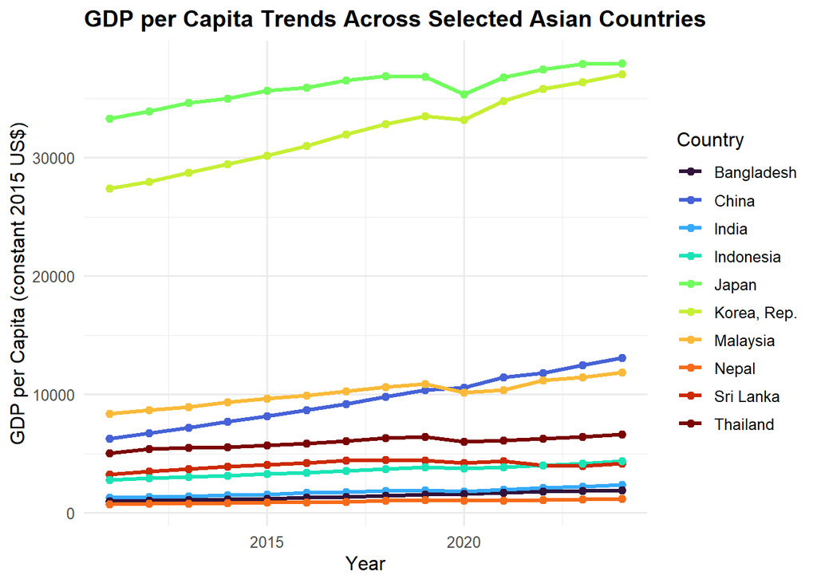

```r
ggplot(
  data_long %>%
    filter(`Series Code` == "NY.GDP.PCAP.KD"),
  aes(
    x = Year,
    y = Value,
    color = `Country Name`
  )
) +
  geom_line(linewidth = 1.2) +
  geom_point(size = 2) +
  scale_color_viridis_d(option = "turbo") +
  labs(
    title = "GDP per Capita Trends Across Selected Asian Countries",
    x = "Year",
    y = "GDP per Capita (constant 2015 US$)",
    color = "Country"
  ) +
  theme_minimal(base_size = 12) +
  theme(
    plot.title = element_text(face = "bold"),
    legend.position = "right"
  )
```

##GDP per capita generally increased across most of the selected Asian countries from 2011 to 2024. Japan and Korea, Rep. remained at the highest level while Nepal and Bangladesh were among the lower levels.

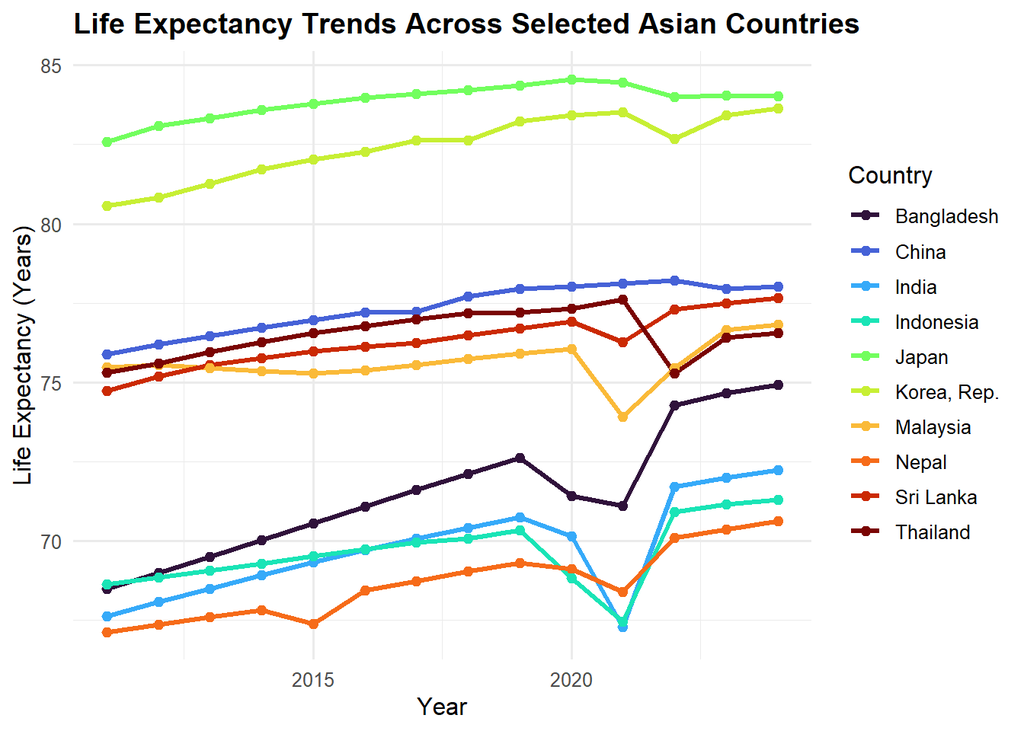

```r
ggplot(
  data_long %>%
    filter(`Series Code` == "SP.DYN.LE00.IN"),
  aes(
    x = Year,
    y = Value,
    color = `Country Name`
  )
) +
  geom_line(linewidth = 1.2) +
  geom_point(size = 2) +
  scale_color_viridis_d(option = "turbo") +
  labs(
    title = "Life Expectancy Trends Across Selected Asian Countries",
    x = "Year",
    y = "Life Expectancy (Years)",
    color = "Country"
  ) +
  theme_minimal(base_size = 12) +
  theme(
    plot.title = element_text(face = "bold")
  )
```

##Life expectancy was relatively stable or gradually increased in most countries. Japan had the highest life expectancy, while Nepal had the lowest among the selected countries. A noticeable fall can also be seen around 2020–2021 for some countries.

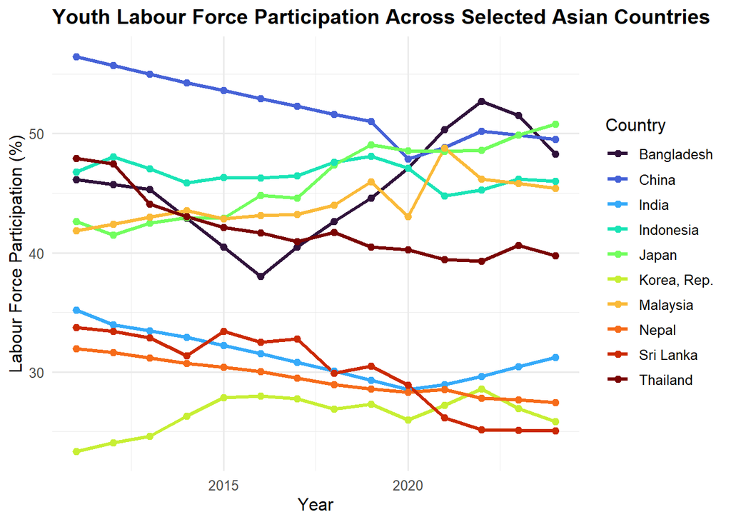

```r
ggplot(
  data_long %>%
    filter(`Series Code` == "SL.TLF.ACTI.1524.ZS"),
  aes(
    x = Year,
    y = Value,
    color = `Country Name`
  )
) +
  geom_line(linewidth = 1.2) +
  geom_point(size = 2) +
  scale_color_viridis_d(option = "turbo") +
  labs(
    title = "Youth Labour Force Participation Across Selected Asian Countries",
    x = "Year",
    y = "Labour Force Participation (%)",
    color = "Country"
  ) +
  theme_minimal(base_size = 12) +
  theme(
    plot.title = element_text(face = "bold")
  )
```

## Youth labour force participation varied across countries and changed differently over time. China had relatively high participation, while Korea, Rep. had the lowest average participation among the selected countries.

```r
average_gdp <- data_long %>%
  filter(`Series Code` == "NY.GDP.PCAP.KD") %>%
  group_by(`Country Name`) %>%
  summarise(
    Average_GDP_per_Capita = mean(Value, na.rm = TRUE)
  ) %>%
  arrange(desc(Average_GDP_per_Capita))

average_gdp
```

```
## # A tibble: 10 × 2
##    `Country Name` Average_GDP_per_Capita
##    <chr>                           <dbl>
##  1 Japan                          36015.
##  2 Korea, Rep.                    32162.
##  3 Malaysia                       10133.
##  4 China                           9542.
##  5 Thailand                        5955.
##  6 Sri Lanka                       4059.
##  7 Indonesia                       3567.
##  8 India                           1775.
##  9 Bangladesh                      1441.
## 10 Nepal                            964.
```

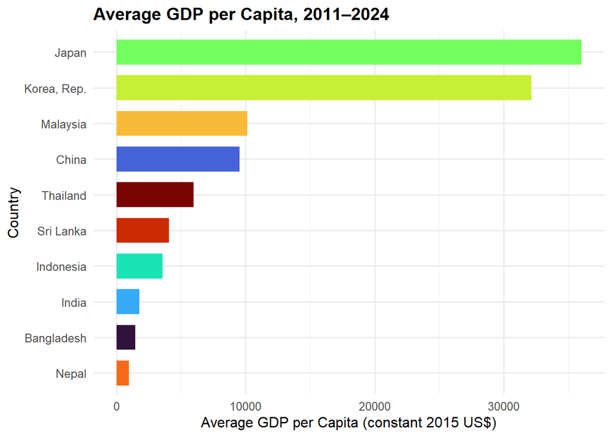

```r
ggplot(
  average_gdp,
  aes(
    x = reorder(`Country Name`, Average_GDP_per_Capita),
    y = Average_GDP_per_Capita,
    fill = `Country Name`
  )
) +
  geom_col(width = 0.7) +
  coord_flip() +
  scale_fill_viridis_d(option = "turbo") +
  labs(
    title = "Average GDP per Capita, 2011–2024",
    x = "Country",
    y = "Average GDP per Capita (constant 2015 US$)",
    fill = "Country"
  ) +
  theme_minimal(base_size = 12) +
  theme(
    plot.title = element_text(face = "bold"),
    legend.position = "none"
  )
```

##Japan had the highest average GDP per capita, followed by Korea, Rep. Nepal had the lowest average GDP per capita among the selected countries.

```r
average_life <- data_long %>%
  filter(`Series Code` == "SP.DYN.LE00.IN") %>%
  group_by(`Country Name`) %>%
  summarise(
    Average_Life_Expectancy = mean(Value, na.rm = TRUE)
  ) %>%
  arrange(desc(Average_Life_Expectancy))

average_life
```

```
## # A tibble: 10 × 2
##    `Country Name` Average_Life_Expectancy
##    <chr>                            <dbl>
##  1 Japan                             83.9
##  2 Korea, Rep.                       82.4
##  3 China                             77.3
##  4 Thailand                          76.5
##  5 Sri Lanka                         76.3
##  6 Malaysia                          75.6
##  7 Bangladesh                        71.5
##  8 India                             69.8
##  9 Indonesia                         69.7
## 10 Nepal                             68.7
```

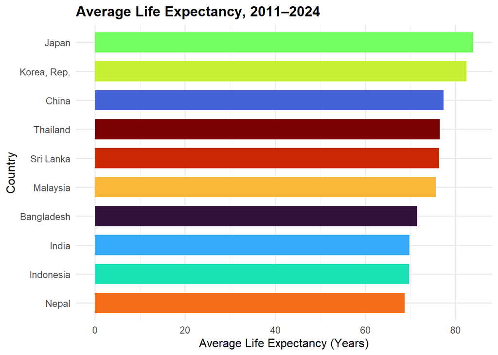

```r
ggplot(
  average_life,
  aes(
    x = reorder(`Country Name`, Average_Life_Expectancy),
    y = Average_Life_Expectancy,
    fill = `Country Name`
  )
) +
  geom_col(width = 0.7) +
  coord_flip() +
  scale_fill_viridis_d(option = "turbo") +
  labs(
    title = "Average Life Expectancy, 2011–2024",
    x = "Country",
    y = "Average Life Expectancy (Years)",
    fill = "Country"
  ) +
  theme_minimal(base_size = 12) +
  theme(
    plot.title = element_text(face = "bold"),
    legend.position = "none"
  )
```

##Japan had the highest average life expectancy, at around 84 years. Nepal had the lowest, at around 69 years. The other countries were mostly between these two levels.

```r
average_youth_labor <- data_long %>%
  filter(`Series Code` == "SL.TLF.ACTI.1524.ZS") %>%
  group_by(`Country Name`) %>%
  summarise(
    Average_Youth_LFPR = mean(Value, na.rm = TRUE)
  ) %>%
  arrange(desc(Average_Youth_LFPR))

average_youth_labor
```

```
## # A tibble: 10 × 2
##    `Country Name` Average_Youth_LFPR
##    <chr>                       <dbl>
##  1 China                        52.1
##  2 Indonesia                    46.6
##  3 Japan                        46.1
##  4 Bangladesh                   45.4
##  5 Malaysia                     44.2
##  6 Thailand                     42.1
##  7 India                        31.3
##  8 Sri Lanka                    30.1
##  9 Nepal                        29.5
## 10 Korea, Rep.                  26.5
```

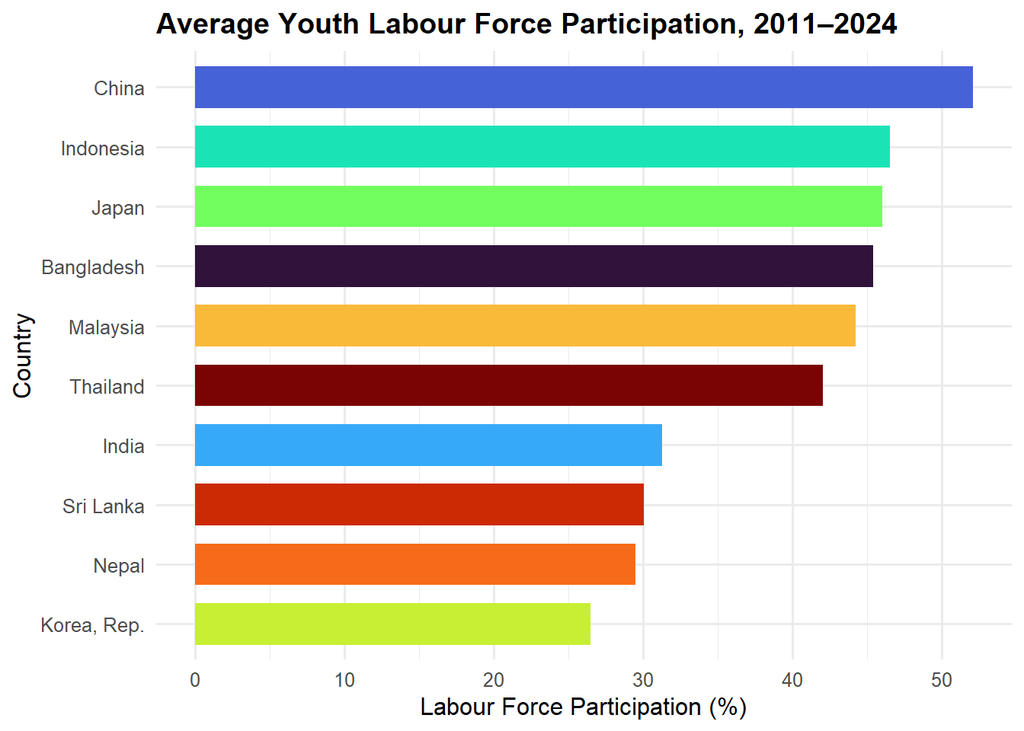

```r
ggplot(
  average_youth_labor,
  aes(
    x = reorder(`Country Name`, Average_Youth_LFPR),
    y = Average_Youth_LFPR,
    fill = `Country Name`
  )
) +
  geom_col(width = 0.7) +
  coord_flip() +
  scale_fill_viridis_d(option = "turbo") +
  labs(
    title = "Average Youth Labour Force Participation, 2011–2024",
    x = "Country",
    y = "Labour Force Participation (%)",
    fill = "Country"
  ) +
  theme_minimal(base_size = 12) +
  theme(
    plot.title = element_text(face = "bold"),
    legend.position = "none"
  )
```

##China had the highest average youth labour force participation, while Korea, Rep. had the lowest. The differences show that youth participation in the labour market varies considerably across the countries.

```r
country_summary <- data_long %>%
  group_by(`Country Name`, `Series Code`) %>%
  summarise(
    Average_Value = mean(Value, na.rm = TRUE),
    .groups = "drop"
  ) %>%
  pivot_wider(
    names_from = `Series Code`,
    values_from = Average_Value
  ) %>%
  rename(
    GDP_per_Capita = `NY.GDP.PCAP.KD`,
    Life_Expectancy = `SP.DYN.LE00.IN`,
    Youth_LFPR = `SL.TLF.ACTI.1524.ZS`
  )

country_summary
```

```
## # A tibble: 10 × 4
##    `Country Name` GDP_per_Capita Youth_LFPR Life_Expectancy
##    <chr>                   <dbl>      <dbl>           <dbl>
##  1 Bangladesh              1441.       45.4            71.5
##  2 China                   9542.       52.1            77.3
##  3 India                   1775.       31.3            69.8
##  4 Indonesia               3567.       46.6            69.7
##  5 Japan                  36015.       46.1            83.9
##  6 Korea, Rep.            32162.       26.5            82.4
##  7 Malaysia               10133.       44.2            75.6
##  8 Nepal                    964.       29.5            68.7
##  9 Sri Lanka               4059.       30.1            76.3
## 10 Thailand                5955.       42.1            76.5
```

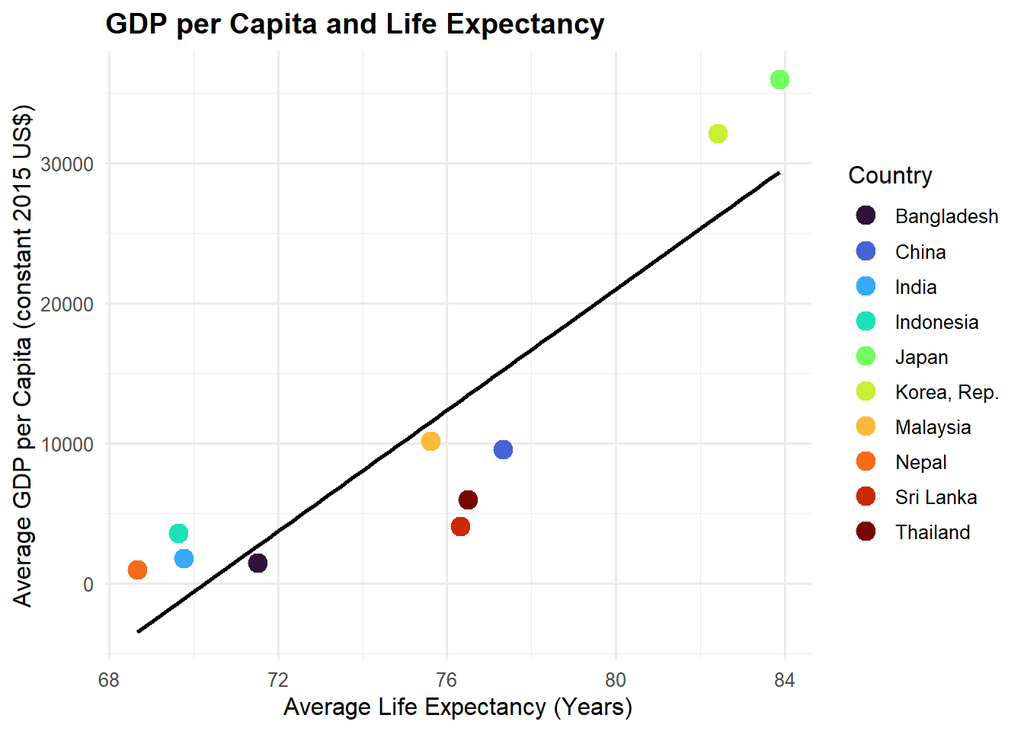

```r
ggplot(
  country_summary,
  aes(
    x = Life_Expectancy,
    y = GDP_per_Capita,
    color = `Country Name`
  )
) +
  geom_point(size = 4) +
  geom_smooth(
    method = "lm",
    se = FALSE,
    color = "black",
    linewidth = 1
  ) +
  scale_color_viridis_d(option = "turbo") +
  labs(
    title = "GDP per Capita and Life Expectancy",
    x = "Average Life Expectancy (Years)",
    y = "Average GDP per Capita (constant 2015 US$)",
    color = "Country"
  ) +
  theme_minimal(base_size = 12) +
  theme(
    plot.title = element_text(face = "bold")
  )
```

##The graph shows a clear positive relationship between life expectancy and GDP per capita. Countries with higher life expectancy generally also had higher GDP per capita. The correlation of 0.89 supports this strong positive relationship.

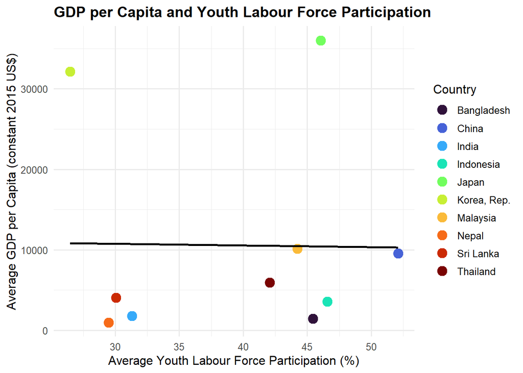

```r
ggplot(
  country_summary,
  aes(
    x = Youth_LFPR,
    y = GDP_per_Capita,
    color = `Country Name`
  )
) +
  geom_point(size = 4) +
  geom_smooth(
    method = "lm",
    se = FALSE,
    color = "black",
    linewidth = 1
  ) +
  scale_color_viridis_d(option = "turbo") +
  labs(
    title = "GDP per Capita and Youth Labour Force Participation",
    x = "Average Youth Labour Force Participation (%)",
    y = "Average GDP per Capita (constant 2015 US$)",
    color = "Country"
  ) +
  theme_minimal(base_size = 12) +
  theme(
    plot.title = element_text(face = "bold")
  )
```

##The graph does not show a clear relationship between youth labour force participation and GDP per capita. This is also supported by the correlation of -0.01, which is very close to zero.

```r
correlation_results <- country_summary %>%
  select(
    GDP_per_Capita,
    Life_Expectancy,
    Youth_LFPR
  ) %>%
  cor(
    use = "complete.obs"
  )

round(correlation_results, 2)
```

```
##                 GDP_per_Capita Life_Expectancy Youth_LFPR
## GDP_per_Capita            1.00            0.89      -0.01
## Life_Expectancy           0.89            1.00       0.08
## Youth_LFPR               -0.01            0.08       1.00
```

##GDP per capita and life expectancy have a strong positive correlation of 0.89. This means countries with higher GDP per capita generally have higher life expectancy.

The correlation between GDP per capita and youth labour force participation is -0.01, showing almost no linear relationship in this dataset.

Life expectancy and youth labour force participation also have a very weak correlation of 0.08.

```r
model <- lm(
  GDP_per_Capita ~ Life_Expectancy + Youth_LFPR,
  data = country_summary
)

summary(model)
```

```
##
## Call:
## lm(formula = GDP_per_Capita ~ Life_Expectancy + Youth_LFPR, data = country_summary)
##
## Residuals:
##      Min       1Q   Median       3Q      Max
## -10110.4  -3382.3    774.6   4054.1   7287.0
##
## Coefficients:
##                  Estimate Std. Error t value Pr(>|t|)
## (Intercept)     -148554.9    31607.7  -4.700  0.00221 **
## Life_Expectancy    2178.8      410.3   5.311  0.00111 **
## Youth_LFPR         -118.2      238.9  -0.495  0.63588
## ---
## Signif. codes:  0 '***' 0.001 '**' 0.01 '*' 0.05 '.' 0.1 ' ' 1
##
## Residual standard error: 6485 on 7 degrees of freedom
## Multiple R-squared:  0.8012, Adjusted R-squared:  0.7444
## F-statistic: 14.11 on 2 and 7 DF,  p-value: 0.003503
```

##Life expectancy has a positive and statistically significant relationship with GDP per capita in the model. Its p-value is 0.00111.

Youth labour force participation has a negative coefficient, but its p-value of 0.63588 shows that its relationship with GDP per capita is not statistically significant in this model.

So, in this dataset, life expectancy is more strongly associated with GDP per capita than youth labour force participation.

```r
regression_results <- data.frame(
  Variable = names(coef(model)),
  Coefficient = coef(model)
)

regression_results
```

```
##                        Variable  Coefficient
## (Intercept)         (Intercept) -148554.9013
## Life_Expectancy Life_Expectancy    2178.7704
## Youth_LFPR           Youth_LFPR    -118.1891
```

#Findings GDP per capita generally increased across the selected Asian countries from 2011 to 2024.

Japan had the highest average GDP per capita and life expectancy among the selected countries.

Youth labour force participation showed considerable differences between countries.

GDP per capita had a strong positive correlation with life expectancy (0.89).

GDP per capita had almost no correlation with youth labour force participation (-0.01).

The regression results show that life expectancy had a significant positive relationship with GDP per capita, while youth labour force participation was not statistically significant.

#Conclusion This study examined GDP per capita, life expectancy and youth labour force participation across ten selected Asian countries from 2011 to 2024. The results show a strong positive relationship between GDP per capita and life expectancy. However, youth labour force participation did not show a clear relationship with GDP per capita. Overall, the analysis highlights differences in economic and social indicators across the selected Asian countries.